# EpiQuant Typing Analysis

### Loading Packages

First, lets go ahead and use a function that will load the packages that we’ll need, and install them if they’re not currently installed.

```r
usePackage<-function(p){
  # load a package if installed, else load after installation.
  # Args:
  #   p: package name in quotes
  if (!is.element(p, installed.packages()[,1])){
    print(paste('Package:',p,'Not found, Installing Now...'))
    install.packages(p, dep = TRUE, repos = "http://cran.us.r-project.org")}
  suppressMessages(require(p, character.only = TRUE))
  print(paste0(p, " loaded."))
}
usePackage("xlsx")
```

```
[1] "xlsx loaded."
```

```r
usePackage("reshape2")
```

```
[1] "reshape2 loaded."
```

```r
usePackage("plyr")
```

```
[1] "plyr loaded."
```

```r
usePackage("grid")
```

```
[1] "grid loaded."
```

```r
usePackage("gridExtra")
```

```
[1] "gridExtra loaded."
```

```r
usePackage("ggplot2")
```

```
[1] "ggplot2 loaded."
```

```r
usePackage("RColorBrewer")
```

```
[1] "RColorBrewer loaded."
```

```r
usePackage("gplots")
```

```
[1] "gplots loaded."
```

```r
usePackage("readr")
```

```
[1] "readr loaded."
```

### Analysis 1: Generating the *EpiMatrix*

Now, we’ll start by loading in a couple different data files:

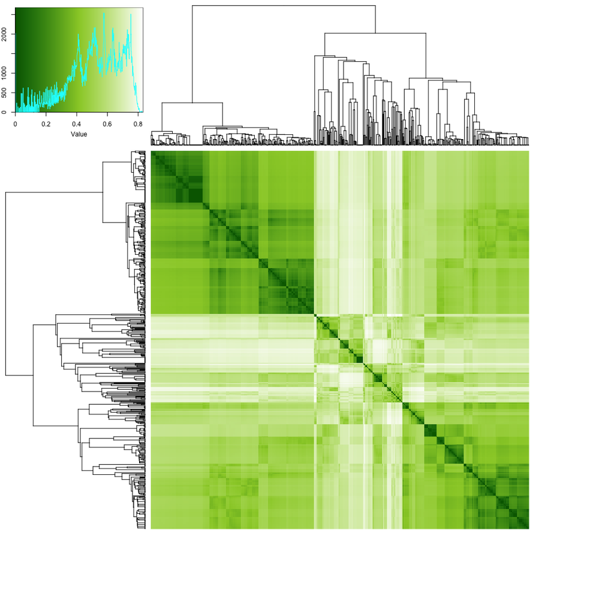

```r
source("helpers/epi-helper.R")
source_pw <- read.table("Pairwise_Source.txt", header = T, sep = '\t')
strain_data <- read.table("Can654_straindata.txt", header = T, sep = '\t')
# Coefficients for source, temporal and geospatial components of the EpiQuant Model: combination of these should add to 1.0
sigma <- 0.5 #source
tau <- 0.3 #temporal
gamma <- 0.2 #geo
epi.table <- EpiTable(strain_data, source_pw, geog_calc(strain_data), temp_calc(strain_data), sigma, tau, gamma)
epi.matrix <- EpiMatrix(epi.table)
EpiHeatmap_pdf(epi.matrix)
```

### Analysis 2: Assessing the Concordance between Epi- and Typing Results

Now that we’ve generated the EpiMatrix file - we can use this to assess the epi-signal from clustered typing data.

To do this, we’ll require an additional file containing the cluster memberships for each method to be tested.

**Here’s what the typing-data should look like:**

```r
typing.data <- read.table("Can654_typingdata_NA.txt", header = T, sep = '\t', row.names = 1, check.names = F)
head(typing.data)
```

```
                     CGF ST CC
Isolate_264 0592.006.004 NA NA
Isolate_400 0592.006.002 NA NA
Isolate_561 0102.001.001 NA NA
Isolate_611 0787.001.001 NA NA
Isolate_497 0904.002.002 NA NA
Isolate_295 0044.003.001 NA NA
```

As you can see here that we’ve got our strain names in rows, and each column represents the fingerprint or sequence type that each strain belongs to. **Next,** we’ll want to actually perform the Epidemiologic Cluster Cohesion measurement for each of the typing clusters, and output that to a human-readable file.

```r
source("helpers/ECC-helper.R")
epi_cohesion_calc(typing.data, epi.matrix)
```

```
[1] "Starting Calculation"
[1] "Done Cut Method  1"
[1] "Done Cut Method  2"
[1] "Done Cut Method  3"
```

```r
# Lets go ahead and save this to an excel file:
 outfile.name <- "ECC_Results(50.30.20).xlsx"
 for(i in 1:length(cut_details)){
   write.xlsx(cut_details[[i]], outfile.name, append = T, sheetName = colnames(typing.data)[i], col.names = T, row.names = F, showNA = T)
 }
```

Our ECC calculator actually saves a global variable called “cut_details” – lets have a look at some of the CGF cluster data from this now:

```r
head(cut_details$CGF)
```

```
  Cluster_Name Cluster_Size       ECC    W_ECC
1 0592.006.004            3 0.9466752 2.840026
2 0592.006.002            1       NaN      NaN
3 0102.001.001            1       NaN      NaN
4 0787.001.001            1       NaN      NaN
5 0904.002.002           15 0.4468350 6.702525
6 0044.003.001           20 0.4997420 9.994839
                                                                                                                                                                                                                                      Members
1                                                                                                                                                                                                         Isolate_264,Isolate_263,Isolate_262
2                                                                                                                                                                                                                                 Isolate_400
3                                                                                                                                                                                                                                 Isolate_561
4                                                                                                                                                                                                                                 Isolate_611
5                                                              Isolate_497,Isolate_442,Isolate_441,Isolate_443,Isolate_625,Isolate_626,Isolate_20,Isolate_70,Isolate_191,Isolate_64,Isolate_66,Isolate_65,Isolate_206,Isolate_107,Isolate_104
6 Isolate_295,Isolate_299,Isolate_298,Isolate_300,Isolate_294,Isolate_296,Isolate_297,Isolate_554,Isolate_301,Isolate_555,Isolate_7,Isolate_11,Isolate_23,Isolate_116,Isolate_126,Isolate_124,Isolate_134,Isolate_139,Isolate_140,Isolate_141
```

The above shows the ECC for each of the CGF Clusters, as well as the “Weighted” version of the data, based upon cluster size - and the members of each CGF Cluster. Now, we have our ECC Analysis results written to a nice Excel file, and can use these results to generate nice plots etc in Excel.. but why would we want to do that when we have the power of **R** at our fingertips!?

#### Comparison of ECC for different resolution methods:

Ok, so we’ve computed the ECC of isolates from our dataset pertaining to how they’re clustered together using:

1. Clonal Complex (i.e. 4/7 housekeeping genes - allelic variation)
2. MLST (7 houskeeping genes - allelic variation)
3. CGF (40 Accessory genes - presence/absence)

Our first hypothesis from this data was that *higher resolution methods generate clusters more specific to the underlying epidemiology.*  
In other words, higher resolution –> smaller clusters containing isolates more highly related to one another –> this increased specificity *should* translate to increased *epidemiological* specificity too, *right?*

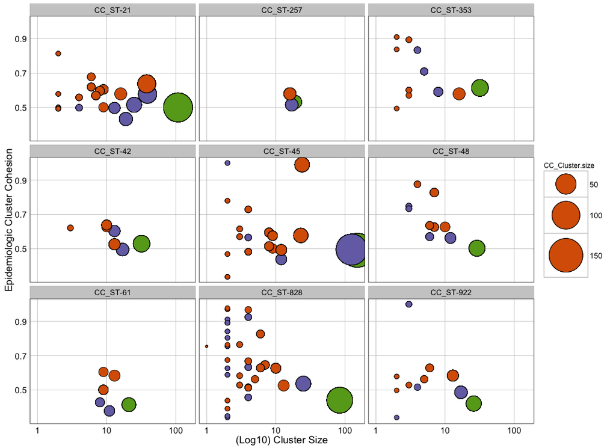

```r
source("helpers/plot_theme.R")
df2 <- read.table("~/Dropbox/0 - Publications_bh/2016_03 EpiQuant Manuscript/EpiQuant_Analysis_2/Can654/cgf_source_vs_temp/ECC_med_results(balanced)_NA.txt", sep = '\t', header = T)
palette <- brewer.pal(8, "Dark2")
bubbleplot <- ggplot(df2[df2$CC_Cluster.size > 18,], aes(x = CC_Cluster.size, y = CC_IEC, size = CC_Cluster.size)) +
  geom_point(fill = palette[5], pch = 21, colour = "black") +
  geom_point(colour = "black", pch = 21, data = df2[df2$CC_Cluster.size > 18,], aes(x = MLST_Cluster.size, y = MLST_IEC, size = MLST_Cluster.size),fill = palette[3]) +
  geom_point(colour = "black", pch = 21, data = df2[df2$CC_Cluster.size > 18,], aes(x = CGF_Cluster.size, y = CGF_IEC, size = CGF_Cluster.size), fill = palette[2]) +
  scale_size(range = c(1, 20)) +  facet_wrap(~CC_ST) + plot_theme() + xlab("(Log10) Cluster Size") + ylab("Epidemiologic Cluster Cohesion") +
  theme(legend.position = 'right') + scale_x_continuous(trans = "log10")
plot(bubbleplot)
```

#### ECC Cluster Analysis for CGF:

OK - So we’re now able to generate ECC values for any type of clustered strain data. What we wanted to test next, was if there was a *variation* in the epidemiological concordance of a typing method depending on what facet of the epidemiologic calculation we were emphasizing. In other words, for a given method (e.g. CGF) do the ECC results change significantly if we focus on **source,** **temporal** or **geospatial** components of the model?

1. *sigma*(0.5) : *tau*(0.3) : *gamma*(0.2) **Balanced**
2. *sigma*(0.8) : *tau*(0.1) : *gamma*(0.1) **Source Emphasis**
3. *sigma*(0.1) : *tau*(0.8) : *gamma*(0.1) **Temporal Emphasis**

```r
cgf <- read.table("CGF_ECC_data(Source_Temp_Balanced).txt", header = T, sep = '\t')
head(cgf) # Have a look at what our data looks like
```

```
   CGF_Subtype Cluster_size ECC_80_10_10 ECC_10_80_10 ECC_50_30_20
1 0731.001.005           17    0.5259353    0.3784038    0.4674783
2 0982.001.002           20    0.5790017    0.4645510    0.5307865
3 0044.003.001           20    0.5837595    0.3653394    0.4997420
4 0926.002.001           29    0.5772023    0.4130000    0.5090952
5 0933.004.002           13    0.5757713    0.3701738    0.4952431
6 0173.002.004            7    0.6194941    0.3919506    0.5480846
```

Since we’ve got our CGF data organized now, lets try looking at the distribution of ECC values for each of the CGF fingerprints:

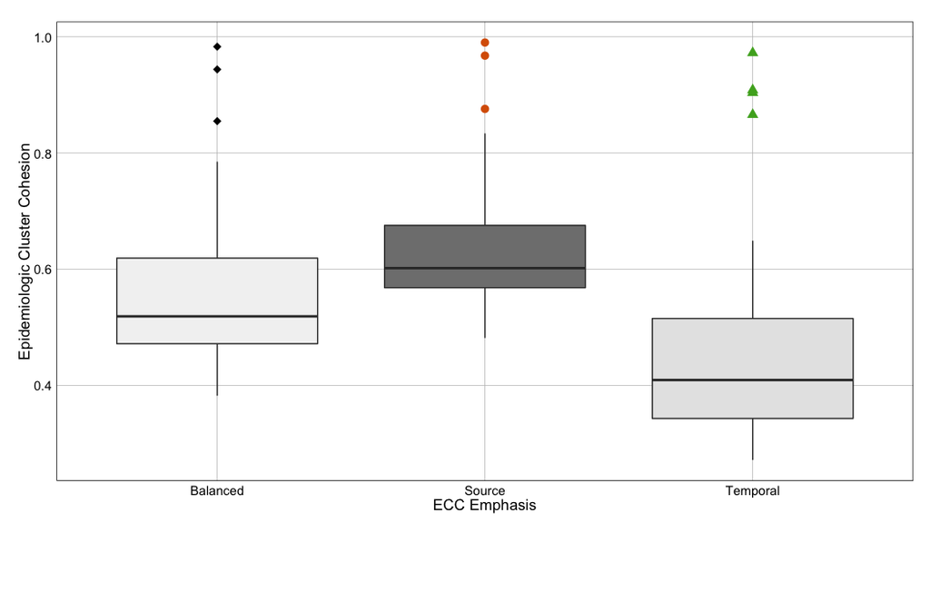

```r
### Boxplot of the total distribution of source vs temporal favoured ECC:
# Grab the CGF data from the ECC analysis data of the different typing systems
box_data <- cgf[cgf$Cluster_size > 3 , c(1, 3, 4, 5)]
# Convert it to long format
cgf_box <- melt(box_data, id.vars = "CGF_Subtype")
# Rename the variables to make more sense
cgf_box$variable <- gsub("ECC_80_10_10", "Source", cgf_box$variable)
cgf_box$variable <- gsub("ECC_10_80_10", "Temporal", cgf_box$variable)
cgf_box$variable <- gsub("ECC_50_30_20", "Balanced", cgf_box$variable)
# Calculate the Quartiles to be able to identify the outlier clusters
cgf_box <- ddply(cgf_box, .(variable), mutate, Q1=quantile(value, 1/4),
                   Q3=quantile(value, 3/4), IQR=Q3-Q1, upper.limit=Q3+1.5*IQR, lower.limit=Q1-1.5*IQR)
# Plot the boxplot data using ggplot
box_cgf <- ggplot(cgf_box, aes(x = variable, y = value, fill = variable)) + plot_theme() +
  geom_boxplot(outlier.colour = NULL, outlier.size = 1, show.legend = F, varwidth = T) + # we'll fill in the outlier colors manually
  scale_fill_manual(values = c("Source" = "grey50", "Temporal" = "grey90", "Balanced" = "grey95")) + # color the boxes
  geom_point(data = cgf_box[cgf_box$value > cgf_box$upper.limit,], aes(x = variable, y = value, col = variable, shape = variable), size = 3) + # plot the outliers using geom_point
  theme(legend.position = "none") + # no legend
  scale_colour_manual(values = c("Source" = "#d95f02", "Temporal" = "#4dac26", "Balanced" = "#010101")) +
  scale_shape_manual(values = c("Source" = 16, "Temporal" = 17, "Balanced" = 18)) + # circles and triangles and diamonds
  labs(y = "Epidemiologic Cluster Cohesion", x = "ECC Emphasis") +
  theme(plot.margin = unit(c(.65, .5, 2.4, .5), "cm"))
plot(box_cgf)
```

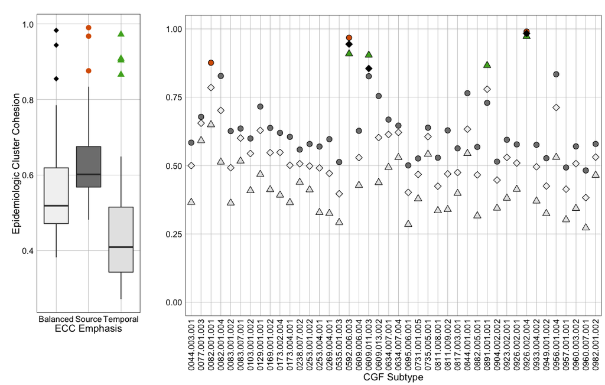

```r
### Plot 2:
# Set up the data for plotting individual cluster results
cgf_outdata <- cgf[cgf$Cluster_size > 3,]
# Dummy negative values for source and temporal outliers
cgf_outdata$source_sig <- 0
cgf_outdata$temp_sig <- 2
cgf_outdata$balanced_sig <- 4
# Change 0 to 1 if outlier source, change 2 to 3 if outlier temporal
outlier_source <- (IQR(cgf_outdata$ECC_80_10_10, na.rm = T) * 1.5) + quantile(cgf_outdata$ECC_80_10_10, na.rm = T)[4]
outlier_temp <- (IQR(cgf_outdata$ECC_10_80_10, na.rm = T) * 1.5) + quantile(cgf_outdata$ECC_10_80_10, na.rm = T)[4]
outlier_balanced <- (IQR(cgf_outdata$ECC_50_30_20, na.rm = T) * 1.5) + quantile(cgf_outdata$ECC_50_30_20, na.rm = T)[4]
cgf_outdata$source_sig[which(cgf_outdata$ECC_80_10_10 > outlier_source)] <- 1
cgf_outdata$temp_sig[which(cgf_outdata$ECC_10_80_10 > outlier_temp)] <- 3
cgf_outdata$balanced_sig[which(cgf_outdata$ECC_50_30_20 > outlier_balanced)] <- 5
# Plot the source and temporal ECC with the identified "outliers" as orange and green shapes instead of grey:
p_cgf <- ggplot(cgf_outdata, aes(x = CGF_Subtype, y = ECC_80_10_10, fill = as.character(source_sig))) + plot_theme() +
  geom_point(size = 3, shape = 21) + theme(axis.text.x  = element_text(angle=90, vjust = 0.5)) +
  geom_point(size = 3, shape = 24, aes(x = CGF_Subtype, y = ECC_10_80_10, fill = as.character(temp_sig))) +
  geom_point(size = 3, shape = 23, aes(x = CGF_Subtype, y = ECC_50_30_20, fill = as.character(balanced_sig))) +
  labs(y = "", title = '', x = 'CGF Subtype') + theme(legend.position = "none") +
  scale_y_continuous(limit = c(0, 1)) + scale_fill_manual(values = c("0" = "grey50","1" = "#d95f02", "2" = "grey90", "3" = "#4dac26", "4" = "grey95", "5" = "#010101"))
# Combine both plots into a single Figure:
cgf_multiplot <- grid.arrange(box_cgf, p_cgf, ncol = 2, widths = c(5, 15))
```

Pretty cool! It looks like the CGF data provides higher association to **Source** compared to **Temporal** associations.

#### Descriptive Statistics for Subtype Clusters and ∆E:

```r
# load our table
epi_subtype_match <- suppressMessages(read_tsv("can654.epi(50_30_20).subtype.matching.txt"))
# save the non redundant data (i.e. no "same-same" isolate name matches)
  mydata <- as.data.frame(epi_subtype_match)
  mydata_nr <- mydata[-which(mydata[,1]==mydata[,2]),]

# calculate the average ∆E for isolates in the same clustersfor each method
paste0("Mean (1-∆E) for pairs of isolates in the same CGF Clusters = ",
      round(1 - mean(mydata_nr[which(mydata_nr$CGF1 == mydata_nr$CGF2), "value"]), 4),
      ", MLST = ",
      round(1 - mean(mydata_nr[which(mydata_nr$MLST1 == mydata_nr$MLST2), "value"]), 4),
      ", CC = ",
      round(1 - mean(mydata_nr[which(mydata_nr$CC1 == mydata_nr$CC2), "value"]), 4)
)
```

```
[1] "Mean (1-∆E) for pairs of isolates in the same CGF Clusters = 0.5429, MLST = 0.5051, CC = 0.4865"
```

```r
# for isolates NOT in the same clusters for each method
paste0("Mean (1-∆E) for pairs of isolates NOT in the same CGF Clusters = ",
      round(1 - mean(mydata_nr[which(mydata_nr$CGF1 != mydata_nr$CGF2), "value"]), 4),
      ", MLST = ",
      round(1 - mean(mydata_nr[which(mydata_nr$MLST1 != mydata_nr$MLST2), "value"]), 4),
      ", CC = ",
      round(1 - mean(mydata_nr[which(mydata_nr$CC1 != mydata_nr$CC2), "value"]), 4)
)
```

```
[1] "Mean (1-∆E) for pairs of isolates NOT in the same CGF Clusters = 0.4719, MLST = 0.4715, CC = 0.4715"
```

```r
# and finally for all isolates regardless of clustering
paste0("Average PW (1-∆E) for the entire dataset = ",
       round(1 - mean(mydata_nr[, "value"]), 4)
       )
```

```
[1] "Average PW (1-∆E) for the entire dataset = 0.4732"
```

```r
# Avg ∆E for each cluster:
n <- 0
CC_Cluster.data <- list()
for(i in unique(mydata_nr$CC1)){
  n <- n+1
  x <- mydata_nr$value[(mydata_nr$CC1 == i) & (mydata_nr$CC2 == i)]
  CC_Cluster.data$ClusterName[n] <- paste0("CC-",i)
  CC_Cluster.data$MeanESym[n] <- 1-mean(x)
  CC_Cluster.data$Length[n] <- length(x)
  }
n <- 0
MLST_Cluster.data <- list()
for(i in unique(mydata_nr$MLST1)){
  n <- n+1
  x <- mydata_nr$value[(mydata_nr$MLST1 == i) & (mydata_nr$MLST2 == i)]
  MLST_Cluster.data$ClusterName[n] <- paste0("ST-",i)
  MLST_Cluster.data$MeanESym[n] <- 1-mean(x)
  MLST_Cluster.data$Length[n] <- length(x)
  }
n <- 0
CGF_Cluster.data <- list()
for(i in unique(mydata_nr$CGF1)){
  n <- n+1
  x <- mydata_nr$value[(mydata_nr$CGF1 == i) & (mydata_nr$CGF2 == i)]
  CGF_Cluster.data$ClusterName[n] <- paste0("CGF-",i)
  CGF_Cluster.data$MeanESym[n] <- 1-mean(x)
  CGF_Cluster.data$Length[n] <- length(x)
}
```